[figure not shown]

Prof. Carlos Andrés Ferrero

# Mineração de Dados

## Pré-Processamento de Dados no Conjunto de Dados Shelter Animals

## Problema: predição do destino de animais em abrigos

- Aproximadamente 7,6 milhões de animais são recolhidos em abrigos. Muitos desses animais tem a sorte de voltar aos seus donos ou ainda serem adotados, mas não todos contam com essa sorte. Muitos animais esperam a vida inteira por uma família que possa adotá-lo. 2.7 milhões de cachorros e gatos sofrem eutanasia todo ano nos estados unidos. O Centro Animal de Austin divulgou dados sobre mais de 25.000 animais para a comunidade de Data Mining auxiliá-los a predizer qual será o destino dos animais. Mais informações no site da [Kaggle](https://www.kaggle.com/c/shelter-animal-outcomes)

## Visão Geral dos Dados

```r
library(data.table)
dt <- fread("data/train.csv")
head(dt,5)
```

| AnimalID | Name | DateTime | OutcomeType | OutcomeSubtype | AnimalType | SexuponOutcome | AgeuponOutcome | Breed | Color |
| --- | --- | --- | --- | --- | --- | --- | --- | --- | --- |
| A671945 | Hambone | 2014-02-12 18:22:00 | Return_to_owner |  | Dog | Neutered Male | 1 year | Shetland Sheepdog Mix | Brown/White |
| A656520 | Emily | 2013-10-13 12:44:00 | Euthanasia | Suffering | Cat | Spayed Female | 1 year | Domestic Shorthair Mix | Cream Tabby |
| A686464 | Pearce | 2015-01-31 12:28:00 | Adoption | Foster | Dog | Neutered Male | 2 years | Pit Bull Mix | Blue/White |
| A683430 |  | 2014-07-11 19:09:00 | Transfer | Partner | Cat | Intact Male | 3 weeks | Domestic Shorthair Mix | Blue Cream |
| A667013 |  | 2013-11-15 12:52:00 | Transfer | Partner | Dog | Neutered Male | 2 years | Lhasa Apso/Miniature Poodle | Tan |

## Ativdade

- (1) Apresente tabelas com a frequência (contagem e percentual) dos possíveis valores dos atributos **AnimalType**, **SexuponOutcome** e **AgeuponOutcome**. Apresente um gráfico para esses atributos que também mostre a frequência ou proporção dos possíveis valores.

### Tabelas de Frequência

```r
n <- nrow(dt)
dt.AnimalType.freq <- dt[,.(contagem = .N, percentual = .N/n),by=.(AnimalType)]
dt.AnimalType.freq
```

| AnimalType | contagem | percentual |
| --- | --- | --- |
| Dog | 15595 | 0.5834487 |
| Cat | 11134 | 0.4165513 |

```r
dt.SexuponOutcome.freq <- dt[,.(contagem = .N, percentual = .N/n),by=.(SexuponOutcome)]
dt.SexuponOutcome.freq
```

| SexuponOutcome | contagem | percentual |
| --- | --- | --- |
| Neutered Male | 9779 | 3.658573e-01 |
| Spayed Female | 8820 | 3.299787e-01 |
| Intact Male | 3525 | 1.318792e-01 |
| Intact Female | 3511 | 1.313555e-01 |
| Unknown | 1093 | 4.089192e-02 |
|  | 1 | 3.741255e-05 |

```r
dt.AgeuponOutcome.freq <- dt[,.(contagem = .N, percentual = .N/n),by=.(AgeuponOutcome)]
head(dt.AgeuponOutcome.freq)
```

| AgeuponOutcome | contagem | percentual |
| --- | --- | --- |
| 1 year | 3969 | 0.14849040 |
| 2 years | 3742 | 0.13999776 |
| 3 weeks | 659 | 0.02465487 |
| 1 month | 1281 | 0.04792547 |
| 5 months | 652 | 0.02439298 |
| 4 years | 1071 | 0.04006884 |

### Gráficos de Frequência

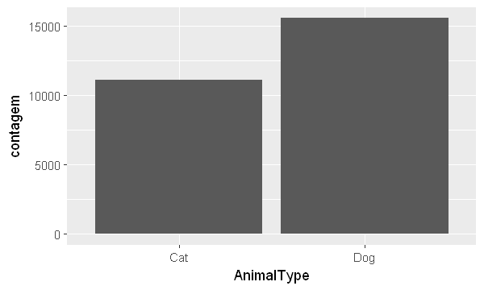

```r
library(ggplot2)
options(repr.plot.width=5, repr.plot.height=3)
ggplot( data = dt.AnimalType.freq, aes(x = AnimalType, y = contagem) ) + geom_col()
```

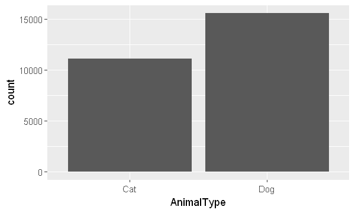

```r
ggplot( data = dt, aes(x = AnimalType) ) + geom_bar()
```

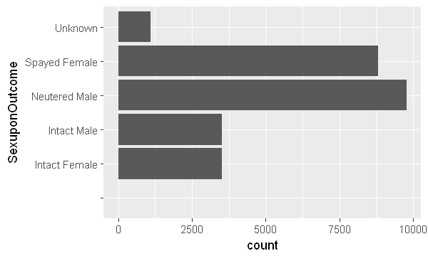

```r
ggplot( data = dt, aes(x = SexuponOutcome) ) + geom_bar() + coord_flip()
```

```r
dt[,c("a","b") := tstrsplit(SexuponOutcome," ", fixed=T)]
head(dt)
```

| AnimalID | Name | DateTime | OutcomeType | OutcomeSubtype | AnimalType | SexuponOutcome | AgeuponOutcome | Breed | Color | a | b |
| --- | --- | --- | --- | --- | --- | --- | --- | --- | --- | --- | --- |
| A671945 | Hambone | 2014-02-12 18:22:00 | Return_to_owner |  | Dog | Neutered Male | 1 year | Shetland Sheepdog Mix | Brown/White | Neutered | Male |
| A656520 | Emily | 2013-10-13 12:44:00 | Euthanasia | Suffering | Cat | Spayed Female | 1 year | Domestic Shorthair Mix | Cream Tabby | Spayed | Female |
| A686464 | Pearce | 2015-01-31 12:28:00 | Adoption | Foster | Dog | Neutered Male | 2 years | Pit Bull Mix | Blue/White | Neutered | Male |
| A683430 |  | 2014-07-11 19:09:00 | Transfer | Partner | Cat | Intact Male | 3 weeks | Domestic Shorthair Mix | Blue Cream | Intact | Male |
| A667013 |  | 2013-11-15 12:52:00 | Transfer | Partner | Dog | Neutered Male | 2 years | Lhasa Apso/Miniature Poodle | Tan | Neutered | Male |
| A677334 | Elsa | 2014-04-25 13:04:00 | Transfer | Partner | Dog | Intact Female | 1 month | Cairn Terrier/Chihuahua Shorthair | Black/Tan | Intact | Female |

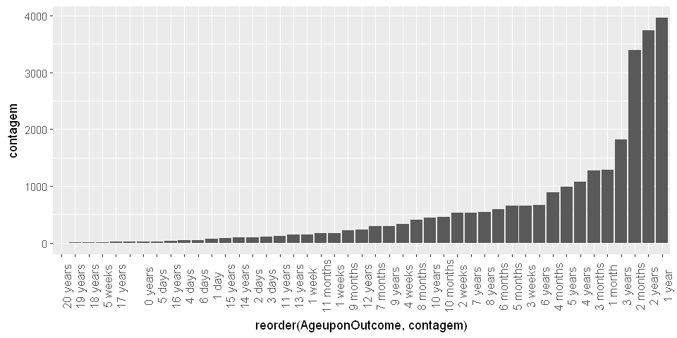

```r
options(repr.plot.width=8, repr.plot.height=4)
ggplot( data = dt.AgeuponOutcome.freq,
           aes(x = reorder(AgeuponOutcome,contagem), y = contagem) ) +
    geom_col() + theme(axis.text.x = element_text(angle = 90, size = 10))
```

- (2) O atributo **AgeuponOutcome** descreve quantidades mas é apresentado de forma nominal, misturando anos, meses e semanas. Transforme o atributo AgeuponOutcome para número de dias **DaysuponOutcome**. Transforme o atributo DaysuponOutcome em um atributo discreto (não substitua o atributo original, crie novos atributos), utilizando as seguintes técnicas:

  a. Intervalos de tamanho pré-definidos. Intervalos: [0;1095), [1095;2555), [2555,4380] dias. (atributo *DaysuponOutcome. intervalo_a*)

  b. Intervalos de igual tamanho, sendo o tamanho 3 intervalos. (atributo *DaysuponOutcome.intervalo_b*)

  c. Intervalos com o mesmo número de elementos, sendo 10 intervalos. (atributo *DaysuponOutcome.intervalo_c*)

  d. Faça gráficos mostrar como ficou a distribuição dos valores utilizando os diferentes intervalos, nas questões a) e b), para a questão c) calcule a média e o desvio padrão de cada intervalo.

#### Transformando o Atributo AgeuponOutcome

1. O atributo é uma string com no máximo dois termos: o número e a unidade de medida (year, month, etc.). Então, divide-se o atributo em duas colunas, uma para cada termo;
2. Transforma-se cada medida em um número em dias;
3. Convertem-se as duas colunas para formato numérico;
4. Faz-se a multiplicação das colunas em uma nova coluna **DaysuponOutcome**;

```r
dt.aux <- data.table(AgeuponOutcome = dt$AgeuponOutcome)
dt.aux <- dt.aux[, c("Numero","Unidade") := tstrsplit(AgeuponOutcome," ",fixed=T) ]
head(dt.aux)
```

| AgeuponOutcome | Numero | Unidade |
| --- | --- | --- |
| 1 year | 1 | year |
| 1 year | 1 | year |
| 2 years | 2 | years |
| 3 weeks | 3 | weeks |
| 2 years | 2 | years |
| 1 month | 1 | month |

```r
dt.aux$Unidade <- gsub("year(\\w?)" ,"365", dt.aux$Unidade )
dt.aux$Unidade <- gsub("month(\\w?)","30",  dt.aux$Unidade )
dt.aux$Unidade <- gsub("week(\\w?)" ,"7",   dt.aux$Unidade )
dt.aux$Unidade <- gsub("day(\\w?)"  ,"1",   dt.aux$Unidade )
dt.aux$Unidade <- gsub("^$"         ,NA ,   dt.aux$Unidade )
head(dt.aux)
```

| AgeuponOutcome | Numero | Unidade |
| --- | --- | --- |
| 1 year | 1 | 365 |
| 1 year | 1 | 365 |
| 2 years | 2 | 365 |
| 3 weeks | 3 | 7 |
| 2 years | 2 | 365 |
| 1 month | 1 | 30 |

```r
dt.aux$Numero <- as.numeric(dt.aux$Numero)
dt.aux$Unidade <- as.numeric(dt.aux$Unidade)
dt.aux$DaysuponOutcome <- dt.aux$Numero * dt.aux$Unidade
head(dt.aux)
```

| AgeuponOutcome | Numero | Unidade | DaysuponOutcome |
| --- | --- | --- | --- |
| 1 year | 1 | 365 | 365 |
| 1 year | 1 | 365 | 365 |
| 2 years | 2 | 365 | 730 |
| 3 weeks | 3 | 7 | 21 |
| 2 years | 2 | 365 | 730 |
| 1 month | 1 | 30 | 30 |

```r
dt$DaysuponOutcome <- dt.aux$DaysuponOutcome
head(dt,4)
```

| AnimalID | Name | DateTime | OutcomeType | OutcomeSubtype | AnimalType | SexuponOutcome | AgeuponOutcome | Breed | Color | a | b | DaysuponOutcome |
| --- | --- | --- | --- | --- | --- | --- | --- | --- | --- | --- | --- | --- |
| A671945 | Hambone | 2014-02-12 18:22:00 | Return_to_owner |  | Dog | Neutered Male | 1 year | Shetland Sheepdog Mix | Brown/White | Neutered | Male | 365 |
| A656520 | Emily | 2013-10-13 12:44:00 | Euthanasia | Suffering | Cat | Spayed Female | 1 year | Domestic Shorthair Mix | Cream Tabby | Spayed | Female | 365 |
| A686464 | Pearce | 2015-01-31 12:28:00 | Adoption | Foster | Dog | Neutered Male | 2 years | Pit Bull Mix | Blue/White | Neutered | Male | 730 |
| A683430 |  | 2014-07-11 19:09:00 | Transfer | Partner | Cat | Intact Male | 3 weeks | Domestic Shorthair Mix | Blue Cream | Intact | Male | 21 |

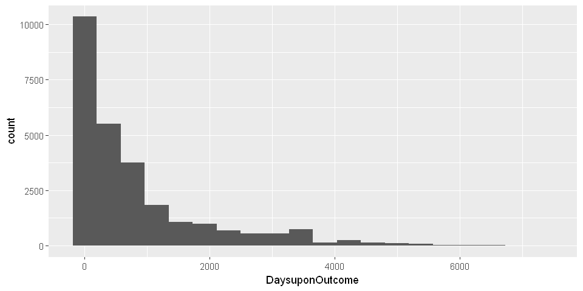

```r
ggplot(data = dt, aes(x=DaysuponOutcome)) + geom_histogram(bins=20)
```

#### Intervalos de Tamanho Pré-definido

```r
x <- dt$DaysuponOutcome
# [0;1095), [1095;2555), [2555,4380]
dt$DaysuponOutcome.intervalo_a  <- ifelse(x < 1095, "[0;1095)",
                                   ifelse(x < 2555, "[1095;555)",
                                   ifelse(x <= 4380, "[2555;4380]",
                                   ifelse(x > 4380, "(4380;inf)", NA))))
```

```r
dt[, .(contagem = .N),by=DaysuponOutcome.intervalo_a]
```

| DaysuponOutcome.intervalo_a | contagem |
| --- | --- |
| [0;1095) | 19601 |
| [1095;555) | 4556 |
| [2555;4380] | 2161 |
| (4380;inf) | 393 |
| NA | 18 |

#### Intervalos de Igual Tamanho

- Relembrando a equação de cálculo do comprimento do intervalo, $L$:

$$L = \frac{max(\mathbf{x}) - min(\mathbf{x}) + 1}{k}$$

- Após isso, usamos divisão de números inteiros para encaixar os valores nos intervalos
- Criando uma função para calcular os intervalos, considerando igual tamanho

```r
intervalos.igual.tamanho <- function( x, k ) {
    min <- min(x, na.rm = T)
    max <- max(x, na.rm = T)
    L <- (max - min + 1) / k
    x.new <- (x - min) %/% L
    x.new
}

dt$DaysuponOutcome.intervalo_b <- intervalos.igual.tamanho(x = dt$DaysuponOutcome, k = 3)
```

```r
dt[, .(contagem = .N),by=DaysuponOutcome.intervalo_b]
```

| DaysuponOutcome.intervalo_b | contagem |
| --- | --- |
| 0 | 24157 |
| 1 | 2304 |
| 2 | 250 |
| NA | 18 |

- Usando o a função *discretize* da biblioteca *arules* obtemos o mesmo resultado de contagem, porem eles já coloca nomes apropriados aos intervalos:

```r
library(arules)
dt$DaysuponOutcome.intervalo_b <- discretize(dt$DaysuponOutcome,
                                              method="interval",
                                              categories = 3)

dt[, .(contagem = .N),by=DaysuponOutcome.intervalo_b]
```

| DaysuponOutcome.intervalo_b | contagem |
| --- | --- |
| [ 0,2433) | 24157 |
| [2433,4867) | 2304 |
| [4867,7300] | 250 |
| NA | 18 |

#### Intervalos de Igual Frequência

```r
intervalos.igual.frequencia <- function( x, k ){
    x.rank <- rank(x, na.last = "keep", ties.method = "min")
    x.new <- intervalos.igual.tamanho(x.rank, k)
    x.new
}

dt$DaysuponOutcome.intervalo_c <- intervalos.igual.frequencia(x = dt$DaysuponOutcome, k = 10)

dt[, .(contagem = .N),by=DaysuponOutcome.intervalo_c]
```

| DaysuponOutcome.intervalo_c | contagem |
| --- | --- |
| 4 | 4816 |
| 5 | 3742 |
| 0 | 3540 |
| 3 | 2818 |
| 8 | 2733 |
| 2 | 1277 |
| 1 | 3408 |
| 9 | 2554 |
| 7 | 1823 |
| NA | 18 |

Também podemos usar um método pronto da biblioteca **arules**

```r
dt$DaysuponOutcome.intervalo_c <- discretize(dt$DaysuponOutcome,
                                              method="frequency",
                                              categories = 10)

dt[, .(contagem = .N),by=DaysuponOutcome.intervalo_c]
```

| DaysuponOutcome.intervalo_c | contagem |
| --- | --- |
| [ 270, 730) | 4816 |
| 730 | 3742 |
| [ 0, 35) | 3540 |
| [ 120, 270) | 2818 |
| [1460,2555) | 2733 |
| 90 | 1277 |
| [ 35, 90) | 3408 |
| [2555,7300] | 2554 |
| 1095 | 1823 |
| NA | 18 |

#### Gráficos

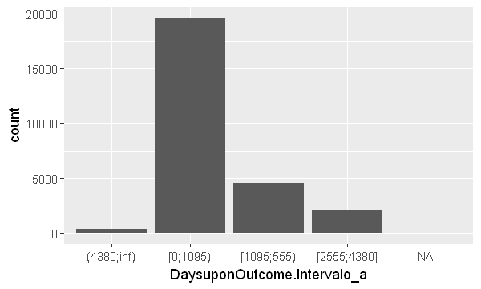

```r
options(repr.plot.width=5, repr.plot.height=3)
ggplot(dt, aes(x = DaysuponOutcome.intervalo_a)) + geom_bar()
```

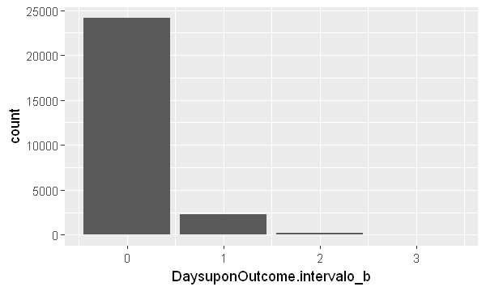

```r
ggplot(dt, aes(x = DaysuponOutcome.intervalo_b)) + geom_bar()
```

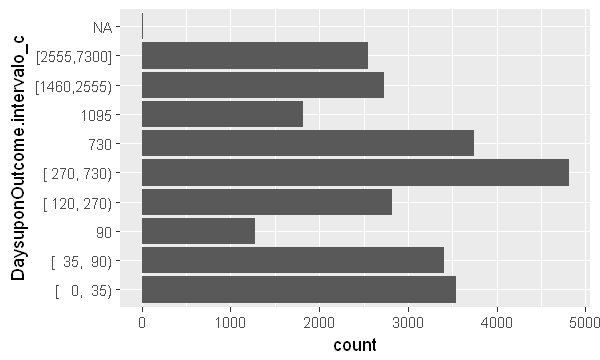

```r
ggplot(dt, aes(x = DaysuponOutcome.intervalo_c)) + geom_bar() + coord_flip()
```

```r
dt[ , .(media = mean(DaysuponOutcome),
        desvio.padrao = sd(DaysuponOutcome)),
   by = DaysuponOutcome.intervalo_c]
```

| DaysuponOutcome.intervalo_c | media | desvio.padrao |
| --- | --- | --- |
| [ 270, 730) | 353.20702 | 26.906988 |
| 730 | 730.00000 | 0.000000 |
| [ 0, 35) | 20.46808 | 9.890320 |
| [ 120, 270) | 165.77715 | 41.791392 |
| [1460,2555) | 1771.44530 | 286.408946 |
| 90 | 90.00000 | 0.000000 |
| [ 35, 90) | 59.91931 | 1.418235 |
| [2555,7300] | 3556.39193 | 921.739588 |
| 1095 | 1095.00000 | 0.000000 |
| NA | NA | NA |

```r
dt[ , .(media = round(mean(DaysuponOutcome)),
        desvio.padrao = round(sd(DaysuponOutcome))),
   by = DaysuponOutcome.intervalo_c]
```

| DaysuponOutcome.intervalo_c | media | desvio.padrao |
| --- | --- | --- |
| [ 270, 730) | 353 | 27 |
| 730 | 730 | 0 |
| [ 0, 35) | 20 | 10 |
| [ 120, 270) | 166 | 42 |
| [1460,2555) | 1771 | 286 |
| 90 | 90 | 0 |
| [ 35, 90) | 60 | 1 |
| [2555,7300] | 3556 | 922 |
| 1095 | 1095 | 0 |
| NA | NA | NA |

- (3) Ainda em relação ao atributo **DaysuponOutcome**, calcule:

  a. Média, desvio padrão.

  b. Mediana, Valor mínimo e Valor máximo.

  c. Crie os novos atributos com os valores normalizados com as técncias de normalização linear, desvio padrão e valor máximo.
- (4) Mostre o novo conjunto de dados incluíndo os atributos criados e seus valores.
- (5) O atributo **DateTime** corresponde à data e hora do animal aochegar ao abrigo. Extraia diferentes informações sobre esse atributo complexo: como o período (manhã, tarde, noite, madrugada), dia da semana em número, dia da semana extenso, entre outros. Procurar na documentação do pacote *libridate*.